# Tutorial: X-ray Image Data

In which we introduce a real astronomical data set, namely an image produced from X-ray CCD data. There's a fair bit of domain-specific information here which is not strictly necessary for this class, but it's useful stuff to see if you haven't worked with imaging data before (regardless of wavelength). Do note that we are still glossing over some things, though, since a more rigorous analysis that accounts for all instrumental and systematic effects would be more involved than we want any tutorials in this class to be.

In terms of the statistical analysis, we will be sticking with things you've done before, just practicing in a more realistic context with less scaffolding. We have, however, intentionally chosen an example where the generative model needs more care than a generic imaging analysis might be, as you'll see below. Unlike previous notebooks, we won't prescribe a specific algorithm or package for you to use. Exactly how to carry out the fits is up to you, although you are expected to follow best practices (testing convergence, etc.).

In more detail, you will

- be introduced to X-ray imaging data;
- fit a simple model describing a point-like (unresolved) source plus an instrumental background to 2 sources in the image;
- check the goodness of fit, and add complexity to either model if needed to describe the data.

Later we will pool results across the class to verify that the telescope's point spread function behaves as expected.

```python
# !pip install cashstatistic incredible pygtc regions

from astropy.coordinates import SkyCoord
from astropy.io import fits
from astropy.visualization import LogStretch
from astropy.wcs import WCS, FITSFixedWarning
from astropy.units import deg as degree_units
logstretch = LogStretch()
import numpy as np
from regions import Regions
import scipy.special as sp
import scipy.stats as st
import matplotlib.pyplot as plt
%matplotlib inline

# this silences an annoying and meaningless warning that seems to be endemic
from warnings import filterwarnings
filterwarnings('ignore', category=FITSFixedWarning)

import cashstatistic as cstat
import incredible as cr
from pygtc import plotGTC

# here are some packages you may want to use (pip install if needed)
#import dynesty
#import emcee
#import lmc
#import pymc
```

```python
thisTutorial = 'xray_image'

## Set the variable `datapath` to the path to the data for this tutorial.

## If you are working in Colab, it will be something like:
#from google.colab import drive
#drive.mount('/content/drive')
#datapath = '/content/drive/MyDrive/Physics267_data/' + thisTutorial + '/'

## Otherwise, it can be an absolute path or relative to the current directory, as in
#datapath = '../../data/' + thisTutorial + '/'

# YOUR CODE HERE
raise NotImplementedError()
```

```python
# do not mess with the housekeeping
# Tests housekeeping
```

## Nature of the data

Modern X-ray CCDs are technologically similar to the CCDs used in optical astronomy: when a photon hits a pixel, one or more electrons are promoted into the conduction band and trapped there until being read out. The main practical difference is that X-ray photons are rarer and their energies are much higher.

This means that:

- Only for exceptionally bright sources will we ever have $>1$ photon hit a given pixel in a single integration, assuming we read out the CCD every few seconds.
- We do not get 1 electron promoted per photon, as is the case in visible wavelength CCDs. Instead, the number of electrons is roughly proportional to the photon's energy, which means that these imaging devices are actually imaging spectrometers.
- When we say "counts" in this context, we mean "pixel activation events" above a certain threshold rather than number of electrons trapped. This way (as in optical astronomy) counts refers to the number of photons detected, plus other events that look like photons to the detector.

For simplicity, we will not be dealing with "raw" data as described above, but with images that have been made from them. In particular, the spectral information has been thrown away, apart from limiting the counts in our image to a particular energy band (0.6-2.0 keV in this case). The original data are from the [Chandra X-ray Observatory](https://cxc.harvard.edu/), and have been cleaned, filtered, and had other things done to them that are beyond the scope of this problem.

The 2 files we need are:

- the image, in units of counts per image pixel, and
- the exposure map.

The latter is a little confusing, as it plays multiple roles. In particular, the exposure map encodes

- vignetting, which effectively decreases the telescope's sensitivity with increasing distance from the optical axis;
- the quantum efficiency of each detector pixel, especially dead or damaged pixels;
- the effective collecting area of the telescope.

The first two of these are functionally like the flat field image used in optical astronomy. The collecting area is "effective" because the efficiency of the optical system varies with energy, and we are combining a fairly wide range in energies into a single image. In detail, the exposure map is computed at a single energy that we assume represents a reasonable average for the photons in the image; this is an acceptable simplification when the effective area and vignetting are not *too* variable over the energy range in question.

The last bullet above means that the exposure map ends up having units of area, specifically $\mathrm{cm}^2$. Oddly enough, in this case, the exposure map does not include the actual exposure time of the observation, despite the name. We will account for that later, giving the final map units of $\mathrm{cm}^2\cdot\mathrm{s}$. This is exactly what we need to transform a model of the sky in $\mathrm{counts}\,\mathrm{s}^{-1}\,\mathrm{cm}^{-2}\,\mathrm{pixel}^{-1}$ into a prediction for the expected number of counts in each image pixel. (The model defined this way is in terms of *surface brightness*, i.e. counts or energy per unit area, time, and solid angle.) Note that, from here on out, "pixel" will refer to an entry in the data arrays (an image pixel), not a physical pixel in the detector.

Both files are in FITS image format, which we can read in using `astropy.io.fits`.

```python
imfits = fits.open(datapath + 'image_0.6-2.0keV.fits.gz')
exfits = fits.open(datapath + 'expmap_1.25kev.fits.gz')
```

This helper function summarizes the contents of each file:

```python
imfits.info()
```

```
Filename: ../../data/public/xray_image/image_0.6-2.0keV.fits.gz
No.    Name      Ver    Type      Cards   Dimensions   Format
  0  PRIMARY       1 PrimaryHDU    1071   (2427, 2436)   int16
```

```python
exfits.info()
```

```
Filename: ../../data/public/xray_image/expmap_1.25kev.fits.gz
No.    Name      Ver    Type      Cards   Dimensions   Format
  0  PRIMARY       1 PrimaryHDU     170   (2427, 2436)   float32
```

In general, FITS files can contain multiple data structures, but each of these has only an image array and supporting header information. The image in `imfits` is of integer type (remember, counts!), while `exfits` is of floating point type.

Here we extract the actual array of data from each object into `numpy` arrays and check how large they are.

```python
im = imfits[0].data
ex = exfits[0].data
print(im.shape, im.dtype)
print(ex.shape, ex.dtype)
```

```
(2436, 2427) >i2
(2436, 2427) >f4
```

Note: If we wanted `im` to be floating point for some reason, we would need to cast it, as in `im = imfits[0].data.astype('float64')`. We won't need to do this here, but it's a useful trick to know.

As mentioned above, we will need the exposure time to convert a model for surface brightness into a prediction for the counts in each pixel. So let's go ahead and extract that information from the FITS header, and multiply it into the exposure map.

```python
print("The exposure time is", imfits[0].header['exposure'], "s")
ex *= imfits[0].header['exposure']
```

```
The exposure time is 103588.8919506 s
```

Let's have a look the image and exposure map. It's often helpful to stretch images on a logarithmic scale because some sources can vary spatially in brightness by orders of magnitude. (It's often still not easy to see any detail without manually adjusting the bias and contrast, but we'll see a simple way to do that interactively in a minute.) The exposure map varies much less, so a linear scale generally works better in that case.

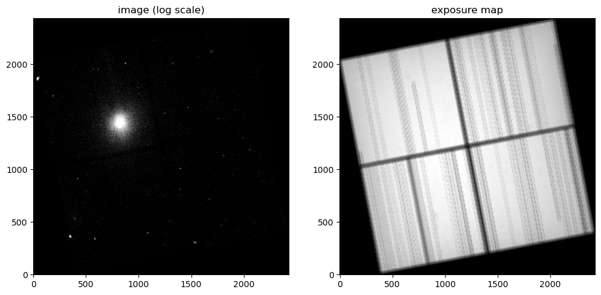

```python
plt.rcParams['figure.figsize'] = (12.0, 6.0)
fig, ax = plt.subplots(1,2);
ax[0].imshow(logstretch(im), cmap='gray', origin='lower');
ax[0].set_title('image (log scale)');
ax[1].imshow(ex, cmap='gray', origin='lower');
ax[1].set_title('exposure map');
```

> **Aside:** An endless source of confusion and bugs is the fact that images are conventionally indexed by *line and sample* (vertical and horizontal position), while we conventionally order coordinates in 2 dimensions $x,y$ (horizontal and vertical). In addition, the usual convention for FITS images orders the lines from the bottom of the image up rather than the top down. Hence, to display the image the right way up, we need to use the `origin='lower'` option to `imshow` above.

Note that information from multiple CCDs has been combined here, and that X and Y in the image arrays correspond to celestial coordinates (right ascension and declination) rather than X and Y on a given detector or in the focal plane. There are fancy packages that can display such images with celestial coordinates labelling the axes (the translation from image pixel position to celestial coordinates is encoded in the FITS header), but we won't need to deal with such things in this exercise.

In the image, we can see:

1. A galaxy cluster (the big blob).
2. Various other sources (smaller blobs). These are point-like sources - mostly active galactic nuclei (AGN) - that have been smeared out by the telescope's point spread function (PSF). You might even be able to see clearly how the size of the PSF increases with distance from the optical axis.
3. A roughly uniform background, consisting of fainter AGN, diffuse X-rays from the Galactic halo and local hot bubble, and events due to particles (solar wind protons and cosmic rays) interacting with the CCD.
4. In the data used for the public solutions, ou might also see a bright streak connecting the brightest part of the cluster to the upper edge of the CCD. This is due to charge transfer inefficiency, as opposed to a physical structure in the Universe. Fortunately, the surface brightness needs to be extremely large for this effect to show up above the background, so you're unlikely to see it in your own data.

The exposure map shows:

1. An overall gradient with distance from the optical axis - this is the vignetting function of the telescope.
2. Fuzzy boundaries between the CCDs (fuzzy because of dithering), and a number of "bad columns" where the exposure has been set to zero (usually this is due to issues with the readout electronics rather than damaged detector pixels). The latter may not correspond to zeros in our exposure map, again because of dithering.

The effects of (2) are also visible in the counts image if you look closely (below). The vignetting is less obvious, since we mostly see background in regions where the vignetting is significant, and most of the background is due to particles that are not vignetted (they aren't focused by the optics, and hit the detector from all directions approximately uniformly).

The exact details will of course vary depending on which data set you were assigned, but in general the comments above should apply.

## Defining the model

We'll be extracting small regions containing unresolved sources and analyzing them independently. The model we'll use for each of these regions can be summarized as follows.

- There is an unresolved source in the region, along with background.
- In practice, the source appears not as a point but has the form of the PSF. We will approximate the PSF as a symmetric 2D Gaussian, which is common.
- The source image is modulated by the exposure map, since it describes X-rays that have traversed the telescope in the intended way. In practice, this means that the model image of the source, which looks like the PSF, should be multiplied by the exposure map.
- The background is a mix of astrophysical X-ray photons not from the source of interest and events caused by particles interacting with the spacecraft and detector. The former are vignetted (see the exposure map in the same way as the source), and the latter are not. Since the particle-induced background is dominant, we will assume a spatially uniform, unvignetted background. Note that, in order for this approximation to be accurate, we want the analysis region to not contain significant emission from the galaxy cluster, nor be so large that the background is non-uniform.

As a function of position, the model surface brightness of the source in $\mathrm{counts}\,\mathrm{s}^{-1}\,\mathrm{cm}^{-2}\,\mathrm{pixel}^{-1}$ can thus be written

$S(x,y) = F \cdot \mathrm{PSF}(x,y|x_\mathrm{s},y_\mathrm{s},\sigma) = F \cdot \mathrm{Normal}(x|x_\mathrm{s},\sigma) \cdot \mathrm{Normal}(y|y_\mathrm{s},\sigma)$,

where

- $F$ is the source flux in $\mathrm{counts}\,\mathrm{s}^{-1}\,\mathrm{cm}^{-2}$,
- $x_\mathrm{s},y_\mathrm{s}$ is the source position,
- $\sigma$ describes the width of the PSF, and
- $x_\mathrm{s}$, $y_\mathrm{s}$, $x$, $y$ and $\sigma$ have units of pixels.

The sampling distribution for these data are Poisson, with the total flux $F$ representing an average (recall the "flux of a source" example way back from the Bayes' Law notes). Our model will therefore need to predict the averge number of counts expected in each pixel, for comparison with the measured counts. The surface brightness above can be converted to a prediction with units of counts by multiplying by the exposure map (taking care of the area $\times$ time) and then integrating the resulting map over the solid angle represented by each pixel.

Because they may come as a surprise to those with previous astronomy experience, we emphasize 2 points.

1. The sampling distribution *really is* Poisson. We cannot get away with assuming that it's Gaussian, as one generally can at longer wavelengths, where typically each pixel recieves hundreds if not thousands of counts in a single exposure.
2. We *really do* have to do the integration over each pixel. This is because this particular detector *undersamples* the PSF near the aimpoint (i.e. the PSF characteristic size is smaller than a pixel). More commonly, the PSF would be *oversampled*, with multiple pixels fitting across a single PSF in the image. In that limit, or when dealing with extended objects that are many pixels in size, it's usually good enough to "integrate" by evaluating the brightness at the center of each pixel and multiplying by the pixel solid angle. That won't do here.

The background is relatively simpler to deal with. Since we're assuming that it's uniform and unvignetted, we can parametrize the background by a single value, $b$, representing the average background counts per pixel.

All together, our prediction for the Poisson mean in the pixel centered at $(x_i,y_j)$ is

$\mu_{i,j} = b + \int dx\,dy \, S(x,y) \, E(x,y)$,

where $E(x,y)$ is the exposure map and the integral is over just pixel $(i,j)$.

As always, add the generative model in the form of a PGM and probabilistic expressions below. Don't forget to include the priors, which we'll discuss and decide on in class.

> Space for PGM and generative model

As usual, we define a standard order and naming convention for the parameters:

```python
param_names = ['xs', 'ys', 'F', 'sigma', 'b']
param_labels = [r'$x_s$', r'$y_s$', r'$F$', r'$\sigma$', r'$b$']
```

## Working with the data

As we've seen above, the image is encoded in a standard `numpy` array. But, recalling the aside, we need to be careful about indexing the array. Specifically, we need to remember that the first array index corresponds to $y$ (the vertical direction in the image), and the second index corresponds to $x$ (horizontal). Alternatively, we could create arrays that hold the $x$ and $y$ indices corresponding to each pixel. This is a little wasteful in terms of computer memory, but allows us to do calculations involving the positions of and distances between points in the image without constantly relying on our human memories to recall something counterintuitive.

The following cell adds such index arrays (`imx` and `imy`) to a data dictionary, along with the image and exposure map.

```python
data = {'im': im, 'ex':ex}
data['imx'], data['imy'] = np.meshgrid(np.arange(im.shape[1]), np.arange(im.shape[0]))
```

In case the description above wasn't clear, a quick look at `imx` and `imy` probably explains what they're good for:

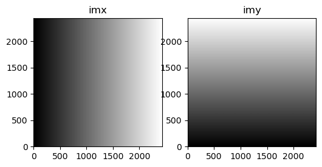

```python
plt.rcParams['figure.figsize'] = (6.0, 6.0)
fig, ax = plt.subplots(1,2);
ax[0].imshow(data['imx'], cmap='gray', origin='lower');
ax[0].set_title('imx');
ax[1].imshow(data['imy'], cmap='gray', origin='lower');
ax[1].set_title('imy');
```

The range of values in each is what you'd expect for indices into arrays of this size:

```python
print(data['imx'].min(), data['imx'].max())
print(data['imy'].min(), data['imy'].max())
```

```
0 2426
0 2435
```

With these defined, we can easily compute, e.g., the distance of each pixel from a given location, $(x_0,y_0)$, without ever having to think about the indexing conventions again.$^1$

### Choosing regions to analyze

Your task in this notebook will be to fit models to 2 of the point-like sources in your image (or more, if you particularly want to). To reiterate, the big, obvious source is a genuinely extended cluster of galaxies, and anything else you can see that isn't plausibly explained by the background is almost certainly a point-like source. But ask if you're unsure.

Since the sources of interest are small, there's no reason for us to analyze the entire image. Instead, you'll use an interactive tool to select specific regions to analyze independently. This tool is called SAOImageDS9 (more often, just DS9) and if you spend any amount of time working with astronomical images, it is well worth becoming familiar with it. You can install DS9 from the [SAO website](https://sites.google.com/cfa.harvard.edu/saoimageds9), or, more simply, use the in-browser version, [JS9](https://www.js9.org/js9.html). In the latter case, note that you can (and should) click and drag the bottom-right corner of the widget to make it as large as your monitor will fit. The mouse controls and menus are slightly different between DS9 and JS9, and we'll assume you're using JS9 below.

As far as we know, it isn't possible to directly open a file from Google drive in either of these tools, so the simplest thing is to download the image FITS file to your local hard drive. Then open it using the menu

- File $\rightarrow$ open local...

Like above, we will want to log-scale it

- Scale $\rightarrow$ log

Finding a good zoom level can be tricky; if you're too zoomed out, many of the sources may not even be visible. It's a good idea to start by looking at the entire image (Zoom $\rightarrow$ zoom to fit), but then zoom in several times on any part of the image that looks interesting.

Move the mouse around over the image. At the top, you can see: the number of counts under the mouse cursor, the celestial coordinates corresponding to that position, and the physical coordinates (yet another coordinate system, defined with respect to the detector module).

Left click + drag will change the contrast and bias; right click + drag will pan the view. It's worth taking a minute to play with the contrast and bias to see how you might change these in order to (1) best see the detail of the cluster or (2) best see the point sources showing up above the background (and/or above the cluster).

For this telescope, the point spread function is quite small near the optical axis (generally, the cluster is centered close to this location) and becomes noticeably larger far from the optical axis, near the edges of the field of view. You might already be able to see this effect by eye. Choose 2 point-like sources to analyze. One should be broadly near the optical axis, though not in a region where there is significant cluster emission. The other should be farther from the optical axis, ideally with a noticeably larger extent.

On to concretely defining the regions. Click Regions $\rightarrow$ circle. A green circle should appear in the middle of the window. Move and resize one of these circles to enclose each of your chosen sources. The radius of each circle should be such that it looks like it encloses the source and enough background that the background level can be constrained. At the same time, don't make the region too large, since the true background is not uniform across the image (especially since the cluster emission counts as background for the purpose of measuring a point source), and we want to avoid that complexity. You should also avoid regions that are nominally between CCDs or close to CCD edges, where dithering is significant and consequently there are rapid changes in the exposure map. Some iteration may be required based on your results below.

Through all of this, keep in mind that there *is* a background, even though most pixels have a value of zero. The fact that we get to infer it from data in the Poisson limit, with 0, 1 or 2 counts usually, is part of the fun.

When you're done, click Regions $\rightarrow$ list, and save the text in the window that pops up in as a string in the cell below. You can also save a region file (this just contains the same text) to disk for safe keeping, in case you want to come back and edit the regions in JS9 again.

```python
# region_string = """
# FK5; circle(...
# FK5; circle(...
# """
# YOUR CODE HERE
raise NotImplementedError()
```

Next, we'll load the region information into a form that can be more easily used in Python...

```python
wcs = WCS(imfits[0].header) # encodes the translation between image and celestial coordinates
regions = Regions.parse(region_string, format='ds9')
```

... and double check that they're what you intended.

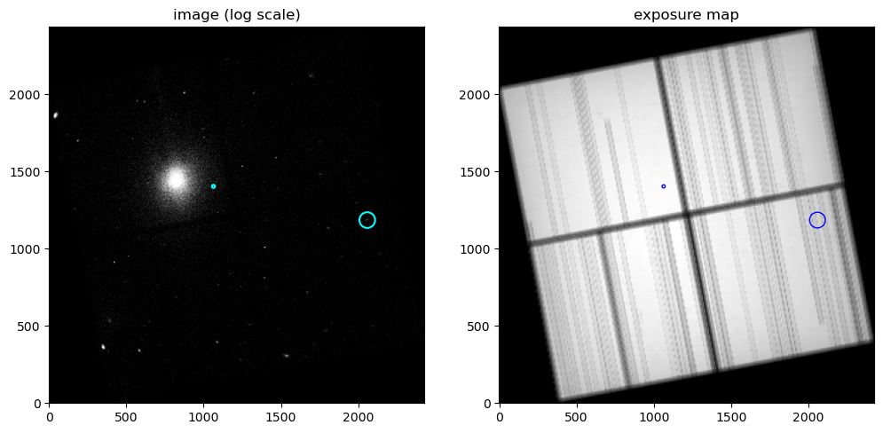

```python
plt.rcParams['figure.figsize'] = (12.0, 6.0)
fig, ax = plt.subplots(1,2);
ax[0].imshow(logstretch(im), cmap='gray', origin='lower');
ax[0].set_title('image (log scale)');
ax[1].imshow(ex, cmap='gray', origin='lower');
ax[1].set_title('exposure map');
for reg in regions:
    r = reg.to_pixel(wcs)
    r.plot(ax=ax[0], edgecolor='cyan', lw=1.5)
    r.plot(ax=ax[1], edgecolor='blue', lw=1.0)
```

Below, we'll provide a little more code to simplify the creating of small "cut out" images based on your regions. Specifically, this object will store its own, smaller copy of `im`, `ex`, `imx` and `imy`. In addition, it will hold `mask`, whose values are `True` inside the circular region of interest and `False` in the corners of the rectangular cut-out that fall outside the circle; this can be used to index any of the other arrays in the usual NumPy fashion.

```python
class Cutout:
    def __init__(self, region, wcs, im, ex, imx, imy):
        region_pix = region.to_pixel(wcs)
        mask = region_pix.to_mask()
        self.im = mask.cutout(im)
        self.ex = mask.cutout(ex)
        self.imx = mask.cutout(imx)
        self.imy = mask.cutout(imy)
        self.mask = (mask.data == 1.0)
        self.extent = [self.imx.min()-0.5, self.imx.max()+0.5, self.imy.min()-0.5, self.imy.max()+0.5]

cutouts = [Cutout(reg, wcs, **data) for reg in regions]
```

To illustrate, here are the tiny images, exposure maps and masks for the 2 regions:

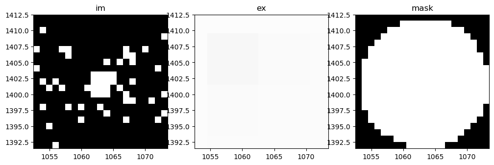

```python
plt.rcParams['figure.figsize'] = (12.0, 8.0)
fig, ax = plt.subplots(1,3);
d = cutouts[0]
ax[0].imshow(logstretch(d.im), cmap='gray', origin='lower', extent=d.extent); ax[0].set_title('im');
ax[1].imshow(d.ex, cmap='gray', origin='lower', vmin=ex.min(), vmax=ex.max(), extent=d.extent); ax[1].set_title('ex');
ax[2].imshow(d.mask, cmap='gray', origin='lower', extent=d.extent); ax[2].set_title('mask');
```

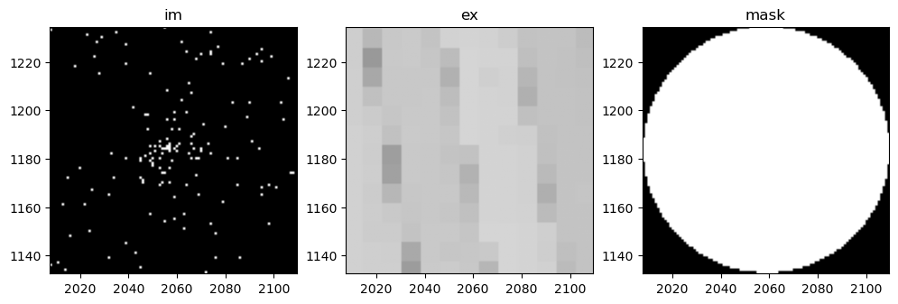

```python
plt.rcParams['figure.figsize'] = (12.0, 8.0)
fig, ax = plt.subplots(1,3);
d = cutouts[1]
ax[0].imshow(logstretch(d.im), cmap='gray', origin='lower', extent=d.extent); ax[0].set_title('im');
ax[1].imshow(d.ex, cmap='gray', origin='lower', vmin=ex.min(), vmax=ex.max(), extent=d.extent); ax[1].set_title('ex');
ax[2].imshow(d.mask, cmap='gray', origin='lower', extent=d.extent); ax[2].set_title('mask');
```

## Visualizing the model

Before setting you loose on fitting the model, let's set up some useful functions for visually comparing the model with the data. The very first thing we'll need, which you'll in any case need to evaluate the likelihood, is a function that produces a model image in counts (the array of $\mu_{i,j}$ from above).

```python
# def model_image(x, y, ex, xs, ys, F, sigma, b):
#     # x and y are "imx" and "imy" arrays corresponding to the model image we want to make
#     # ex is the exposure map of the same shape
#     # xs, ys, F, sigma and b are scalar parameter values
#     # returns an array of the mean predicted counts in each pixel

# YOUR CODE HERE
raise NotImplementedError()
```

Based on inspection of one of the cut-outs above, come up with a guess at the model parameters.

```python
# i = ... # index of the cut-out you want to use in this section
# guess = {'xs':..., 'ys':..., 'F':..., 'sigma':..., 'b':...}

# YOUR CODE HERE
raise NotImplementedError()
```

Let's test out the `model_image` function.

```python
d = cutouts[i]
mod = model_image(d.imx, d.imy, d.ex, **guess)
```

Below, we'll provide 2 functions to help visualize the goodness of the model. The first straightforwardly displays the data, the model prediction, and their difference (residual = model - data).

```python
def model_check_image(d, mod):
    # d is a Cutout object
    # mod is a model image of the same shape
    plt.rcParams['figure.figsize'] = (12.0, 3.0)
    fig, ax = plt.subplots(1,3);
    ax[0].imshow(d.im, cmap='gray', origin='lower', extent=d.extent); ax[0].set_title('im');
    ax[1].imshow(mod, cmap='gray', origin='lower', vmin=d.im.min(), vmax=d.im.max(), extent=d.extent); ax[1].set_title('model');
    resim = ax[2].imshow(mod-d.im, cmap='gray', origin='lower', extent=d.extent); ax[2].set_title('residual'); plt.colorbar(resim, ax=ax[2]);
```

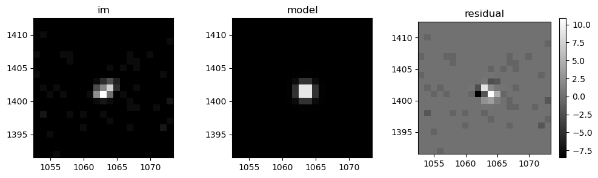

```python
model_check_image(d, mod)
```

The second will crudely compare the profiles of the data and model, i.e. the counts in a series of concentric annuli. You can (and should, for a large region), specify the outer radii in pixel units of the annuli as a list with the `r2` argument below. The plotting function will compare the profiles, redundantly, in terms of counts, counts/pixel and surface brightness, with approximate $\sqrt{N}$ uncertainties on the model.

```python
class Profile:
    def __init__(self, img, xs, ys, r2=None):
        if r2 is None:
            r2 = np.arange(np.round(img.im.shape[0]/2))[1:]
        else:
            r2 = np.array(r2)
        r1 = np.concatenate(([0.0], r2[:-1]))
        N = np.zeros(r1.shape)
        E = np.zeros(r1.shape)
        npix = np.zeros(r1.shape)
        d = np.sqrt((img.imx - xs)**2 + (img.imy - ys)**2)
        for i in range(len(N)):
            j = np.logical_and(np.logical_and(d >= r1[i], d < r2[i]), img.mask)
            N[i] += img.im[j].sum()
            E[i] += img.ex[j].sum()
            npix[i] += j.sum()
        r = 0.5*(r1 + r2)
        assert np.all(npix > 0)
        self.r1 = r1
        self.r2 = r2
        self.r = r
        self.N = N
        self.E = E
        self.npix = npix

def model_check_profile(d, mod, xs, ys, r2=None, **kwargs):
    # d is a Cutout object
    # mod is a model image of the same shape
    # xs and ys are scalar coordinates of the profile center
    # r2 is optionally a list or array of outer radii for the annuli defining the profile
    # other kwargs are ignored
    p = Profile(d, xs, ys, r2)
    tmp = d.im
    d.im = mod
    m = Profile(d, xs, ys, r2)
    d.im = tmp
    fig, ax = plt.subplots(1,3, figsize=(20.0, 4.5))
    ax[0].semilogx(p.r, p.N, '.', label='data');
    ax[0].errorbar(m.r, m.N, yerr=np.sqrt(m.N), fmt='-', label='model');
    ax[0].legend();
    ax[1].loglog(p.r, p.N/p.npix, '.');
    ax[1].errorbar(m.r, m.N/m.npix, yerr=np.sqrt(m.N)/m.npix, fmt='-');
    ax[2].loglog(p.r, p.N/p.E, '.');
    ax[2].errorbar(m.r, m.N/m.E, yerr=np.sqrt(m.N)/m.E, fmt='-');
    ax[0].set_ylabel('Total counts');
    ax[1].set_ylabel('Average counts/pixel');
    ax[2].set_ylabel('Average surface brightness');
    for i in range(3): ax[i].set_xlabel('Radius (pixels)');
```

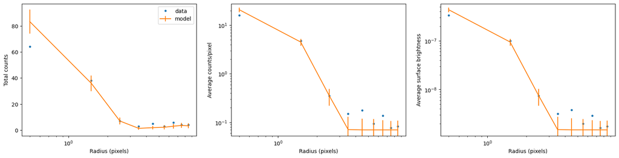

```python
model_check_profile(d, mod, **guess) # optionally include r2
```

The 2D residual plot can be helpful for refining the center and normalization of your source model, but the background-dominated region is never going to be very informative. In contrast, the profile plots can be good for eyeballing the background level, and potentially for tweaking the value of `sigma`. With some iteration, this should help you come up with reasonable starting points for both source regions.

```python
# we can provide a test of the model_image function here, based on the current values of `guess` and `d`
# Tests modimg (1 point)
```

## Inference for the first region

You are now on your own to sample the posterior of the above model for the first region chosen above (`cutouts[0]`). We will not prescribe a specific method or package, but for uniformity of grading there are a few requirements.

#### Requirements:

- Produce equally weighted samples from the posterior and store them (after removing any burn-in and doing any thinning you feel necessary) in `chains1` in the form of multiple (**at least 4**) chains, as either a list of $N_\mathrm{samples} \times N_\mathrm{params}$ arrays, or a single $N_\mathrm{chains} \times N_\mathrm{samples} \times N_\mathrm{params}$ array (i.e., in one of the formats that `incredible` understands). This doesn't mean you necessarily have to use an MCMC method, but if you use some other method you must be able to extract results in the above format (even if it means artificially breaking samples into multiple "chains"). There will be cells below for plotting traces, and tests for convergence and a minimum number of effectively independent samples, that will assume this format, and that must be passed. Parameters should be ordered as in `param_names`.
- "Approximate Methods" methods are not allowed. We want the real posterior.
- **Explain your work** with the kind of verbosity you're accustomed to seeing in these notebooks. Leave in any work that was part of your process (e.g., performing an initial optimization, plotting traces before removing burn-in), even if they aren't strictly necessary for the final product.

Remember that your analysis should only include the data within a circular region, which is a subset of the data included in the `Cutout` object.

You can use and/or add as many cells as needed below. Since you'll be doing this inference more than once, we really suggest you package up as much code as possible in functions/classes to make it reusable.

```python
# YOUR CODE HERE
raise NotImplementedError()
```

```
CPU times: user 11.2 s, sys: 39.3 ms, total: 11.2 s
Wall time: 11.2 s
```

### Testing the first fit

Welcome back! We will now look at standard diagnostics of the chains you stored in `chains1`. First, traces.

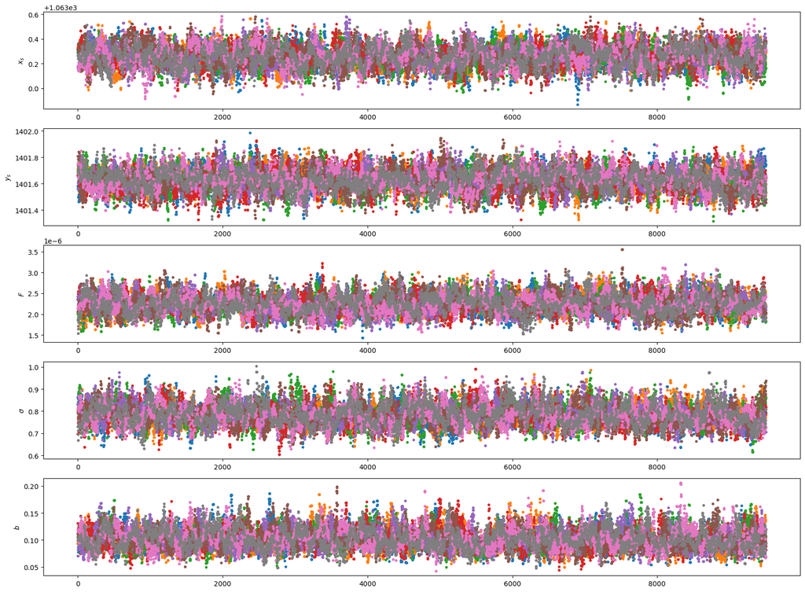

```python
# Checkpoint traces1_byI 0
fig, ax = plt.subplots(len(param_names), 1, figsize=(20, len(param_names)*3));
if chains1.__class__ == list:
    cr.plot_traces(chains1[:min(8,len(chains1))], ax, labels=param_labels);
else:
    cr.plot_traces(chains1[:min(8,chains1.shape[0]),:,:], ax, labels=param_labels);
# End checkpoint
```

Next the Gelman-Rubin convergence criterion and effective number of samples. Adjust the value of `maxlag` below if needed. Note that the test thresholds below are somewhat arbitrary, but fine for practice.

```python
maxlag = 1000 # you might need to change this
```

```python
# Checkpoint converge1 1
R = cr.GelmanRubinR(chains1)
print("R =", R)
assert np.all(R < 1.05)
neff = cr.effective_samples(chains1, maxlag=maxlag, throw=True)
print("neff =", neff)
assert np.all(neff > 500)
# End checkpoint
```

```
R = [1.00192338 1.00354688 1.00097319 1.00140866 1.00521685]
```

```
neff = [1334.12944313 1326.89536819 1405.07232659 1328.42876639 1219.61677311]
```

Assuming these tests were passed, we'll combine the chains and look at a triangle.

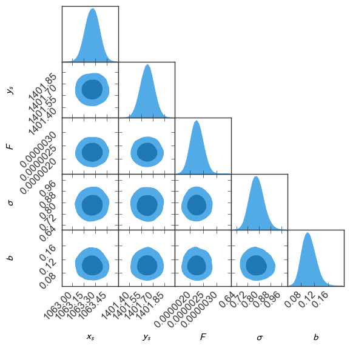

```python
# Checkpoint triangle1_byI 0
chain1 = np.concatenate(chains1, axis=0)
plotGTC(chain1, paramNames=param_labels, figureSize=6, customLabelFont={'size':12}, customTickFont={'size':12});
# End checkpoint
```

If everything above looks good, we can now turn to visually checking the fit to the data. For simplicity, we'll use the posterior mean for this. The cells below will make the 2D residual and 1D profile plots from earlier. Set the `r2` argument in the profile function if needed to get useful signal-to-noise, e.g. in the background-dominated region. (Our solutions will not do this, and therefore may not look great.)

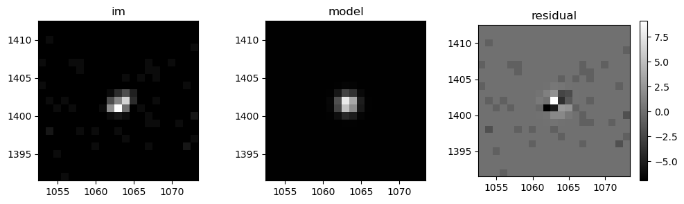

```python
chain1_mean = {k:x for k,x in zip(param_names, chain1.mean(axis=0))}
mod = model_image(cutouts[0].imx, cutouts[0].imy, cutouts[0].ex, **chain1_mean)
model_check_image(cutouts[0], mod)
```

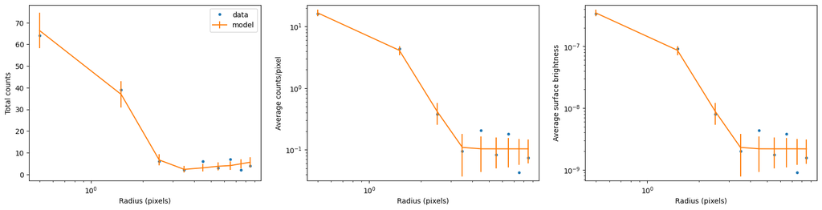

```python
model_check_profile(cutouts[0], mod, **chain1_mean, r2=None)
```

Finally, we will do a goodness of fit test analogous to the $\chi^2$ test you've seen in the Model Evaluation notes. Recall that, for a Gaussian likelihood, the sum of squared residuals (which in that case is $-2$ times the log of the best-fit likelihood) follows the $\chi^2$ distribution. Testing whether the achieved value is consistent with coming from the theoretical distribution gave us a simple way to decide whether the model being fitted was adequate to explain the data.

In our case, the likelihood is Poisson, and to avoid constantly saying "$-2$ times the log-likelihood", we instead conventionally call this quantity the Cash statistic, $C$ ([Cash 1979](http://adsabs.harvard.edu/abs/1979ApJ...228..939C)). The theoretical distribution of the best-fit $C$ is not $\chi^2$; in fact, it isn't any simple, analytic distribution. However, it turns out that when the number of data points (pixels in our case) is large enough, is is well approximated as Gaussian, with parameters that can be computed from the best-fitting model expectation. Because the log-likelihood (and therefore $C$) and the Gaussian mean and variance are all additive, one can compute all of these things pixel-wise and then sum them to evaluate the model overall. The calculations themselves are seriously annoying if technically simple ([Kaastra 2017](https://ui.adsabs.harvard.edu/abs/2017A%26A...605A..51K)), so we will use an implementation from the `cashstatistic` package, called below.

(Note that this will harmlessly throw `RuntimeWarning`s about infinities that are actually ignored.)

```python
# Checkpoint cash1
c = cstat.cash_mod_expectations(mod)
print("For the posterior mean model:")
print("Actual C:", cstat.cash_mod(mod[cutouts[0].mask], cutouts[0].im[cutouts[0].mask]).sum())
print("Theoretical C:", c[0][cutouts[0].mask].sum(), "+/-", np.sqrt(c[1][cutouts[0].mask].sum()))
# End checkpoint
```

```
For the posterior mean model:
Actual C: 179.19745385489006
Theoretical C: 169.6655381431362 +/- 17.115914190756534
```

We are being slightly naughty by testing the posterior mean rather than the maximum likelihood fit, although the former is quite defensible in the Bayesian context.

To finish this section, compute the "p-value" equivalent for the posterior mean, quantifying the agreement between the actual and theoretical Cash statistics.

```python
# pval1 = ...

# YOUR CODE HERE
raise NotImplementedError()
```

```python
print(pval1)
```

```
0.28879661785100375
```

If your p-value indicates inconsistency with the data, say $p<0.01$ or $p>0.99$, either there is a mistake or the model is not a good one for this cut-out. In the latter case, you can either go back and choose a different source, or (more interestingly) modify the model so that it *can* describe the data. This is generally only necessary for very bright point sources, where the data can clearly show that the PSF is not, in fact, a symmetric Gaussian; often fitting 2 Gaussians with a common center and different widths is sufficient in those cases. (Actually, changing the model would make our automatic grader very upset. So maybe don't do that in the notebook that you turn in.)

```python
# test of the p-value calculation
# Tests pval1_test (1 point)
```

```python
# Here we will compare your chains to our own solution.
# This will use your value of `guess` as a starting point. Make sure it isn't so poor as to seriously delay convergence.
# Tests post1_test (1 point)
```

## Inference for the second region

Perform the same inference for the second region (`cutouts[1]`). All the same requirements apply as in the last section. Store your posterior chains in `chains2`. Note that your fit will likely take longer, since you should have chosen a source where the PSF was larger and thus be using a larger cut-out.

```python
# YOUR CODE HERE
raise NotImplementedError()
```

```
CPU times: user 58.3 s, sys: 1.07 s, total: 59.4 s
Wall time: 59.4 s
```

### Testing the second fit

Welcome back! We will now look at standard diagnostics of the chains you stored in `chains2`, just like in the last section. First, traces.

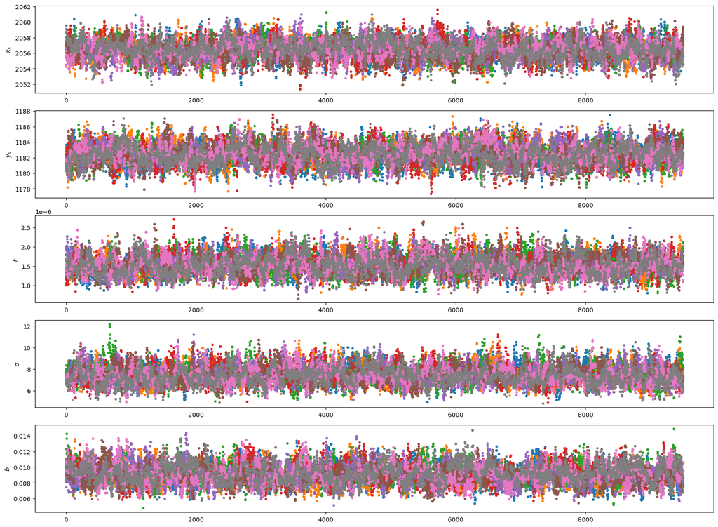

```python
# Checkpoint traces2_byI 0
fig, ax = plt.subplots(len(param_names), 1, figsize=(20, len(param_names)*3));
if chains2.__class__ == list:
    cr.plot_traces(chains2[:min(8,len(chains1))], ax, labels=param_labels);
else:
    cr.plot_traces(chains2[:min(8,chains1.shape[0]),:,:], ax, labels=param_labels);
# End checkpoint
```

Next the Gelman-Rubin convergence criterion and effective number of samples. Adjust the value of `maxlag` below if needed. Note that test thresholds are somewhat arbitrary, but fine for practice.

```python
maxlag = 1000 # you might need to change this
```

```python
# Checkpoint converge2 1
R = cr.GelmanRubinR(chains2)
print("R =", R)
assert np.all(R < 1.05)
neff = cr.effective_samples(chains2, maxlag=maxlag, throw=True)
print("neff =", neff)
assert np.all(neff > 500)
# End checkpoint
```

```
R = [1.00359517 1.00559442 1.00197622 1.00331865 1.00290018]
```

```
neff = [1401.57137918 1144.1145209  1433.18402564 1436.52100597 1224.62608386]
```

Assuming these tests were passed, we'll combine the chains and look at a triangle.

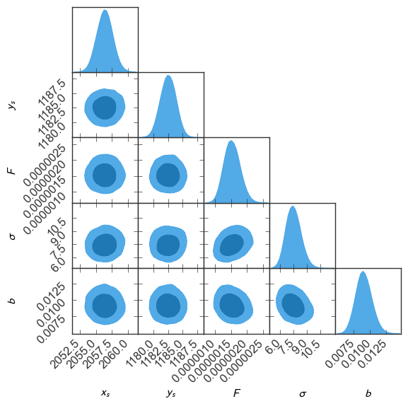

```python
# Checkpoint triangle2_byI 0
chain2 = np.concatenate(chains2, axis=0)
plotGTC(chain2, paramNames=param_labels, figureSize=6, customLabelFont={'size':12}, customTickFont={'size':12});
# End checkpoint
```

If everything above looks good, we can now turn to visually checking the fit to the data. For simplicity, we'll use the posterior mean for this. The cells below will make the 2D residual and 1D profile plots from earlier. Set the `r2` argument in the profile function if needed to get useful signal-to-noise, e.g. in the background-dominated region. (Our solutions will not do this, and therefore may not look great.)

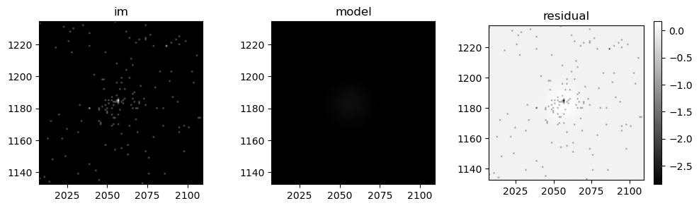

```python
chain2_mean = {k:x for k,x in zip(param_names, chain2.mean(axis=0))}
mod = model_image(cutouts[1].imx, cutouts[1].imy, cutouts[1].ex, **chain2_mean)
model_check_image(cutouts[1], mod)
```

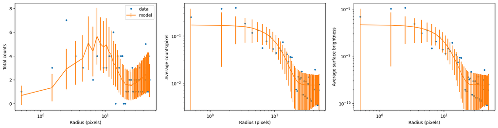

```python
model_check_profile(cutouts[1], mod, **chain2_mean, r2=None)
```

Finally, we will do the same goodness-of-fit test as before.

```python
# Checkpoint cash2
c = cstat.cash_mod_expectations(mod)
print("For the posterior mean model:")
print("Actual C:", cstat.cash_mod(mod[cutouts[1].mask], cutouts[1].im[cutouts[1].mask]).sum())
print("Theoretical C:", c[0][cutouts[1].mask].sum(), "+/-", np.sqrt(c[1][cutouts[1].mask].sum()))
# End checkpoint
```

```
For the posterior mean model:
Actual C: 964.2914200351138
Theoretical C: 970.4231481946476 +/- 66.82310961707066
```

As before, compute the "p-value" equivalent for the posterior mean, quantifying the agreement between the actual and theoretical Cash statistics.

```python
# pval2 = ...

# YOUR CODE HERE
raise NotImplementedError()
```

```python
print(pval2)
```

```
0.5365558728950738
```

Once again, your p-value should indicate consistency with the data, say $0.01<p<0.99$, to move on.

```python
# test of the p-value calculation
# Tests pval2_test (1 point)
```

```python
# Here we will compare your chains to our own solution.
# This will use your value of `guess` as a starting point. Make sure it isn't so poor as to seriously delay convergence.
# Tests post2_test (1 point)
```

## Parting thoughts

As advertised, this notebook hasn't really tested any statistical concepts that you haven't used before, but instead practiced them in a more complete (and more specifically astrophysical) context than we have mostly done up to now. Hopefully it was fun to play with image data in a regime where very common shortcuts are ill advised.

Before you go, let's summarize the PSF width at the position of your sources, and their distance from the optical axis. We will do this the safe way, using `astropy` to properly compute distance on a sphere (although we would be fine using a locally flat approximation in pixel coordinates instead).$^1$

```python
aimpoint = SkyCoord(imfits[0].header['RA_PNT'], imfits[0].header['DEC_PNT'], unit=degree_units)
print('Aimpoint:', aimpoint)
source1 = wcs.pixel_to_world(chain1_mean['xs'], chain1_mean['ys'])
print('Source 1:', source1)
source2 = wcs.pixel_to_world(chain2_mean['xs'], chain1_mean['ys'])
print('Source 2:', source2)
```

```
Aimpoint: <SkyCoord (ICRS): (ra, dec) in deg
    (210.24658422, 2.84514201)>
Source 1: <SkyCoord (ICRS): (ra, dec) in deg
    (210.22547678, 2.87280947)>
Source 2: <SkyCoord (ICRS): (ra, dec) in deg
    (210.08957961, 2.87279814)>
```

Here are the distances between the aimpoint and each source, and the corresponding PSF size, which we will compare across the class.

```python
print('Source 1:', round(aimpoint.separation(source1).arcmin, 2), 'arcmin; PSF sigma =', round(chain1_mean['sigma'], 2), 'pixels')
print('Source 2:', round(aimpoint.separation(source2).arcmin, 2), 'arcmin; PSF sigma =', round(chain2_mean['sigma'], 2), 'pixels')
```

```
Source 1: 2.09 arcmin; PSF sigma = 0.78 pixels
Source 2: 9.55 arcmin; PSF sigma = 7.48 pixels
```

```python
# moar housekeeping
# Tests housekeeping2
```

#### Endnotes

##### Note 1

Note that using $\Delta$RA and $\Delta$Dec (or any global angular coordinates) in the Pythagorean Theorem is generally *not* correct, even for small distances. This is a whole thing that we will not delve further into, because geometry. Meditate upon the appearance of Antarctica in a Mercador projection if you doubt us.